# 任务分解

## 分享课题 实验因子设计方法调研

## 目标

1.不知道影响因子时，如何设计条件

2.知道影响因子,不知道水准时如何设计条件

```
2020年8月29日03:26:07
```

# BackGround

- 实验因子&DOE

## 实验因子设计方法

因子试验设计是指**多因子析因实验**的设计方法。最初的设计是考察各因子所有水平一切可能的组合对反应变量（即反应值）的影响，所以称“全面实施方案”。

## DOE （DESIGN OF EXPERIMENT试验设计）

实验设计已广泛运用了从航天业到一般**生产制造业**的**产品质量改善、工艺流程优化**甚至已运用到医学界。通过对产品质量，工艺参数的量化分析，寻找关键因素，控制与其相关的因素。根据实际需求，判别与选择不同的实验设计种类，**设计你的实验步骤，发现如何控制各种影响因素，以最少的投入，换取最大的收益，**从而使产品质量得以提升，工艺流程最优化。

# Question Analysis

## DOE（试验设计）目的

##### 不知道影响因子时，如何设计条件 → DOE 实验设计步骤

1.筛选主要显著的因子  
2.找出最佳之生产条件组合  
3.证明最佳生产条件组合有再现性

## 正交试验

##### 知道影响因子,不知道水准时如何设计条件

### 定义

正交试验设计法是研究与处理多因素试验的一种科学方法。它利用一种规格化的表格——正交表，**挑选试验条件**，安排试验计划和进行试验，并**通过较少次数的试验，找出较好的生产条件**，即最优或较优的试验方案。

### 用途

正交试验设计主要用于调查复杂系统（产品、过程）的某些特性或多个因素对系统（产品、过程）某些特性的影响，识别系统中更有影响的因素、其**影响的大小**，以及因素间可能存在的相互关系，以促进产品的设计开发和过程的优化、控制或改进现有的产品（或系统）。

**拓展：**

#### 析因实验设计

##### 定义

析因法又称析因试验设计、析因试验等。它是研究变动着的**两个或多个因素**效应的有效方法。许多试验要求考察两个或多个变动因素的效应。例如，若干因素对产品质量的效应；对某种机器的效应；对某种材料的性能的效应；对某一过程燃烧消耗的效应等等。将所研究的因素按全部因素的所有水平（位级）的一切组合逐次进行试验，称为析因试验，或称完全析因试验，简称析因法。

##### 用途

用于新产品开发、产品或过程的改进、以及安装服务，通过较少次数的试验，找到优质、高产、低耗的因素组合，达到改进的目的。

# Conclusion

## DOE（试验设计）用处

1. 科学合理地安排实验，从而减少实验次数、缩短实验周期，提高了经济效益。
2. **从众多的影响因素中找出影响输出的主要因素**。
3. 分析影响因素之间交互作用影响的大小。
4. **分析**实验**误差**的影响大小，**提高实验精度**。
5. **找出较优的参数组合**，并通过对实验结果的分析、比较，找出达到最优化方案进一步实验的方向。

# 实验设计基本流程

## 假说演绎法(Hypothetico-deductive-method) → 假设检验总结

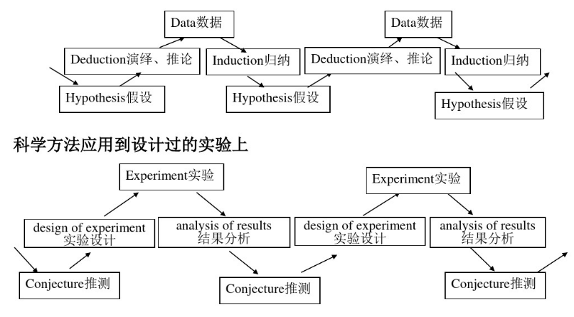

## 生产过程中的实验设计

从源头出发，设计管控产品品质

[figure not shown]

## 实验因素

##### 因素：可控因素 和 不可控因素

##### 变量

1.与因素的关系 因素的不同水平即为变量值

2.多种变量 使用不同方法分析

```
枚举（头脑风暴）→实验设计（表格）→因子联系确认：主效应&相互作用...（统计图）
```

**方法:** 正交试验&析因实验

3.试验设计方法

三次设计法：  
.系统设计  
.参数设计  
.容差设计

4.方差设计&极差分析

价差分析 **优点** 计算简单 比较直观 **缺点** 无法确定因素影响大小  
[引] 参考资料：https://wenku.baidu.com/view/bb23e5a9f011f18583d049649b6648d7c0c70868.html?fr=search-1

# 析因设计

拓展内容：https://wenku.baidu.com/view/98537068dfccda38376baf1ffc4ffe473368fd28.html

##### Pass

2020年8月29日04:21:16

# Appendix

## DOE Lesson Contents

```
一、DOE简介
    1、DOE的定义
    2、DOE的历史与发展
    3、DOE的用途
    4、DOE的成功运用案例
二、DOE类型
    1、全因子DOE
    2、分部DOE
    3、筛选DOE
    4、中心复合DOE
    5、Box-Behnken DOE
    6、田口静态DOE
    7、均匀DOE
三、设计一个DOE的步骤（案例模拟）
    1、定义问题，定义项目
    2、确定可能的因变量
        关于选择因子与其水平的策略
        输入因子的类型与应用
        干扰因子
        可控因子
        常数项
    3、选择设计类型
    4、分析数据，标识主要影响因素
    5、提出解决方案
    6、重复实验以确认结果
    7、过程能力评估
    8、制定优化方案
四、DOE的有效性
    1、内部有效性
    2、外部有效性
    3、统计结论的有效性
五、DOE结果分析
    1、因素影响与交互影响
    2、极差分析
    3、ANOVA方差分析
        单向方差分析
        双向方差分析
    4、回归分析
六、如何利用Minitab进行DOE分析
    1、在Minitab中的图形分析
        正态概率图
        Pareto
        主效果图
        交互效果图
    2、在Minitab中的统计分析
        ANOVA
        多元回归
        简化模式
七、DOE在应用中的问题
    1、因素影响与交互影响试验的阶段性
    2、极差分析因子水平的选择
    3、测量误差
    4、重复与反复
    5、随机化
    6、分块
    7、诊断与残差点
    8、优化试验（EVOP）
八、设计DOE计划的成功关键
    1、团队合作
    2、知识技术的跨功能
    3、定义问题
    4、可量化的改善目标
九、DOE应用实例
```

# DOE Learning

###### 2020年8月29日13:39:39

## DOE的前提

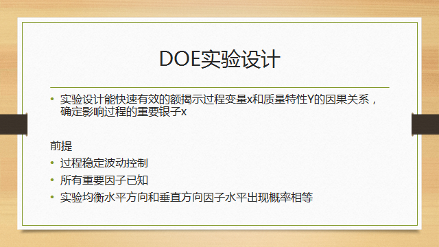

## DOE的种类

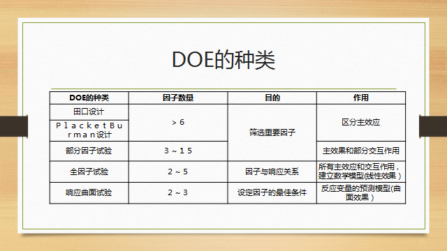

## DOE的步骤

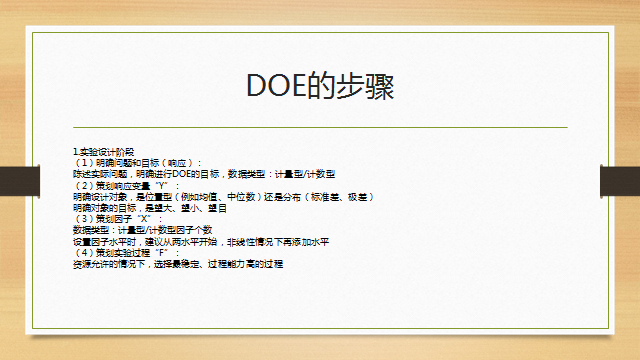

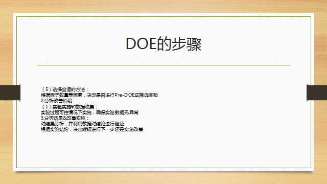

## minitab 全因子试验案例分析

### 因子

minitab/统计/DOE/因子/创建因子分析

### 水平

水平设定以高低二水平

### 数据类型

计量型&计数型

### 设计方案

设置数

### 其他概念

重复 区组 随机化 主效应 交互作用

1. **残差**：是指实际观察值与估计（拟合）之间的差，差越小代表拟合越好，反之相反。
2. **Rsq** 线性拟合R平方决定系数，反应因变量的全部变异能通过回归关系被自变量解释的比例。
3. R平方为**回归平方和与总离差平方和**的比值，表示总离差平方和中可以由回归平方和解释的比例，这一比例越大越好，模型越精确，回归效果越显著。
4. R平方介于0~1之间，越接近1，回归拟合效果越好，一般认为超过0.8的模型拟合优度比较高。  
   ### 目标特性  
   确定试验分析的目标 望目（期望目标值） 望小（期望趋近小） 望大

### 其他 minitab 因子分析功能的使用

# Update History

Rev.0 File Created @2020年8月29日03:26:07  
Rev.1 The First Update@2020年8月29日05:00:57  
Rev.2 To be update@TBD DOE设计课件  
其他参考资料：https://wenku.baidu.com/view/fc965c6305a1b0717fd5360cba1aa81145318f46.html?fr=search-1  
Rev.3 参考资料 实验设计-初阶辅助教材 qs14  
Rev.4 文档格式转化导出@2020年8月30日23:24:36